# CausalImpact Google

```r
summary(impact_temp)
```

```
## Posterior inference {CausalImpact}
##
##                          Average          Cumulative
## Actual                   51972            467744
## Prediction (s.d.)        52470 (2609)     472229 (23478)
## 95% CI                   [47287, 57501]   [425582, 517506]
##
## Absolute effect (s.d.)   -498 (2609)      -4485 (23478)
## 95% CI                   [-5529, 4685]    [-49762, 42162]
##
## Relative effect (s.d.)   -0.77% (5%)      -0.77% (5%)
## 95% CI                   [-9.6%, 9.9%]    [-9.6%, 9.9%]
##
## Posterior tail-area probability p:   0.41257
## Posterior prob. of a causal effect:  59%
##
## For more details, type: summary(impact, "report")
```

Next to do: Add in unemployment for under 24 versus over 24 Add tax income for government

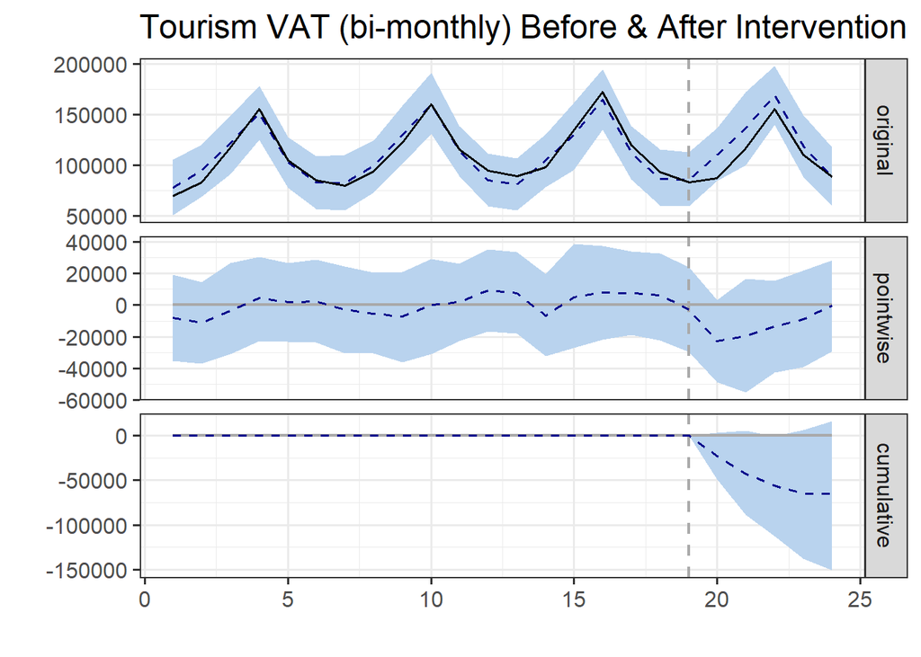

```r
# this is the trickiest one to do, data is bi monthly, so need to make each grouping by monthly
complete <- month # Restart the formula

bimonthly <- month

bimonthly$bimonthly <- rep(1:(length(rownames(bimonthly))/2), each=2)
# create column of duuplicated values
#Filter our to columns with information for the period we are forecasting
bimonthly <- bimonthly %>% filter(date > '2015-12-31') %>% filter(date < '2019-12-31')
#
bimonthly2 <- bimonthly[,109]
icelandcolumns <- grep('iceland', colnames(bimonthly))
bimonthly <- bimonthly[,-c(icelandcolumns)]

bimonthly <- bimonthly[ , colSums(is.na(bimonthly))==0]

bimonthly <- cbind(bimonthly,bimonthly2)
# Starting here just go in order.

bimonthly <- bimonthly %>% dplyr::group_by(bimonthly) %>% summarise(
  date = min(date),
  unemprate_faroe = mean(unemprate_faroe, na.rm=T),
  unemprate_greenland = mean(unemprate_greenland, na.rm=T),
  visitors_faroe = sum(visitors_faroe,na.rm=T),
  visitors_greenland = sum(visitors_greenland, na.rm=T),
  taxable_wage_faroe = sum(taxable_wage_faroe, na.rm=T),
  #no_employees_greenland = sum(no_employees_greenland, na.rm=T), # Avoiding duplicates
  exports_local_currency_faroe = sum(exports_local_currency_faroe, na.rm=T),
  exports_local_currency_greenland = sum(exports_local_currency_greenland, na.rm=T),
  imports_local_currency_faroe = sum(imports_local_currency_faroe, na.rm=T),
  imports_local_currency_greenland = sum(imports_local_currency_greenland, na.rm=T),
  landings_weight_faroe = sum(landings_weight_faroe, na.rm=T),
  landings_weight_greenland = sum(landings_weight_greenland, na.rm=T),
  landings_local_curency_faroe = sum(landings_local_curency_faroe, na.rm=T),
  landings_local_curency_greenland = sum(landings_local_curency_greenland, na.rm=T),
  #all_age_unemployed_faroe = mean(all_age_unemployed_faroe, na.rm=T), # avoiding duplicates
  #all_age_unemplotment_rate_faroe = mean(all_age_unemplotment_rate_faroe, na.rm=T), # avoiding duplicates
  `16_24_unemplotment_rate_faroe` = mean(`16_24_unemplotment_rate_faroe`, na.rm =T),
  `16_24_unemployed_faroe` = mean(`16_24_unemployed_faroe`, na.rm =T),
  `25_74_unemployed_faroe` = mean(`25_74_unemployed_faroe`, na.rm =T),
  `25_74_unemployment_rate_faroe` = mean(`25_74_unemployment_rate_faroe`, na.rm =T),
VAT_total_iceland = mean(VAT_total_iceland, na.rm=T))

bimonthly <- bimonthly[,-1] %>% relocate(VAT_total_iceland) %>% relocate(date)
bimonthly <- bimonthly[ , colSums(is.na(bimonthly))==0]


impact_temp <- ts(data = bimonthly[-c(1)])


pre.period <- as.numeric(c(1, 19))

post.period <- as.numeric(c(20,24))


impact_temp <- CausalImpact(impact_temp,pre.period, post.period,model.args=list(niter=5000))

plot(impact_temp) + ggtitle("Tourism VAT (bi-monthly) Before & After Intervention")
```

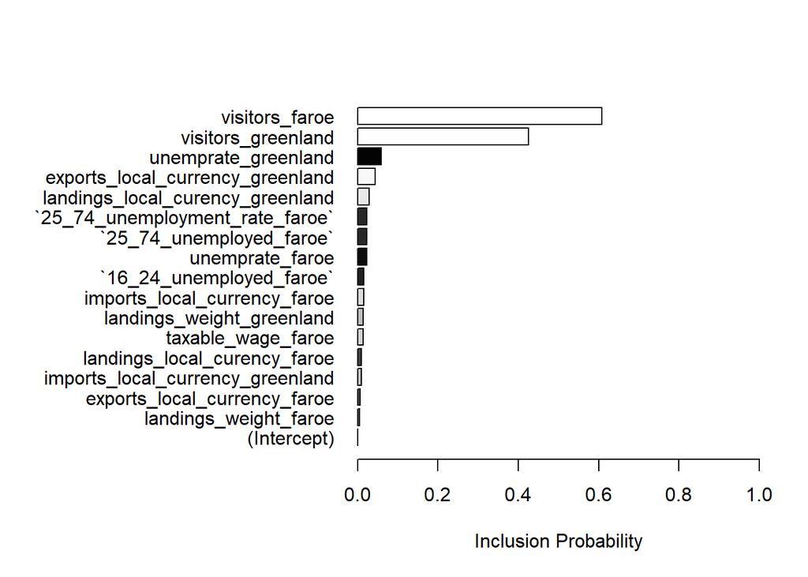

```r
plot(impact_temp$model$bsts.model, "coefficients") # predictors for Tax Revenues
```

```r
summary(impact_temp)
```

```
## Posterior inference {CausalImpact}
##
##                          Average            Cumulative
## Actual                   111523             557613
## Prediction (s.d.)        124555 (8656)      622773 (43280)
## 95% CI                   [108283, 141659]   [541413, 708296]
##
## Absolute effect (s.d.)   -13032 (8656)      -65160 (43280)
## 95% CI                   [-30137, 3240]     [-150683, 16200]
##
## Relative effect (s.d.)   -10% (6.3%)        -10% (6.3%)
## 95% CI                   [-21%, 3%]         [-21%, 3%]
##
## Posterior tail-area probability p:   0.0678
## Posterior prob. of a causal effect:  93%
##
## For more details, type: summary(impact, "report")
```

```r
#64894 Reduction (millions ISK) ~ 1 krona = .007135
#600000 Tourist Decline

#Implies About

64894*1000000 *.007135 / 600000
```

```
## [1] 771.6978
```

```r
# Back of the envelope about 771 Dollars Per Tourist lost in revenue to the government

#OR
64894*1000000 *.007135
```

```
## [1] 463018690
```

```r
#463,018,690 in foregone Revenue
#
#Government Revenue in 2018 was: 1,146.5 Billion ISK
1146.5*1000000000*.007135
```

```
## [1] 8180277500
```

```r
#8.18 Billion US
#lost .46 Billion in Revenue
.46/8.18
```

```
## [1] 0.05623472
```

```r
# approximate 5.6% of 2018 government revenue

# Comparatively, the Revenue of WOWAIR in 2017 was about 52 Billion ISK
52000000000*.007135
```

```
## [1] 371020000
```

```r
# 371 Million USD

#Basically the loss ot the
```

government was greater than the revenues of wowair alltogether

My Idea Is Basically, If I get CONSISTENT Results when doing a quarterly AND Annual Comparison, then it seems legitimate

Then quarterly comparison - can probably do this in R with grouping - then just add in quarterly data - check for consistency of results

Then annual comparison - can probably do this in R with grouping - then just add in quarterly data - check for consistency of results AGAIN!

THEN: Do an overall placebo check

Why will this be convincing? 1. Consistency of results with varying lengths of time 2. Indicator Placebos (i.e. fish landings / imports / construction) 3. Placebo across different years